# Count Regression: Poisson, Negative Binomial, and Probing Interactions

Predicting physician office visits among older adults

Author

Jheanelle Walters

Published

November 20, 2026

# 1. Data and exploration

## The data

These data come from the `NMES1988` dataset in the `AER` package, which contains 4,406 adults aged 66 and older from the 1987 to 1988 US National Medical Expenditure Survey. The outcome is `visits`, the number of physician office visits. The analysis uses five predictors, described below. The reference groups are average for self-perceived health, male for gender, and no for private insurance.

| Variable | Description | Role |
| --- | --- | --- |
| visits | Number of physician office visits | Outcome |
| chronic | Number of chronic conditions | Predictor |
| health | Self-perceived health: poor, average, or excellent (reference: average) | Predictor |
| gender | Male or female (reference: male) | Predictor |
| school | Years of education | Predictor |
| insurance | Covered by private insurance: no or yes (reference: no) | Predictor |

## Describing the outcome

Table 1: Descriptive statistics for the number of physician office visits

| n | Mean | Variance | Proportion of zeros | Maximum |
| --- | --- | --- | --- | --- |
| 4,406 | 5.77 | 45.69 | 0.155 | 89 |

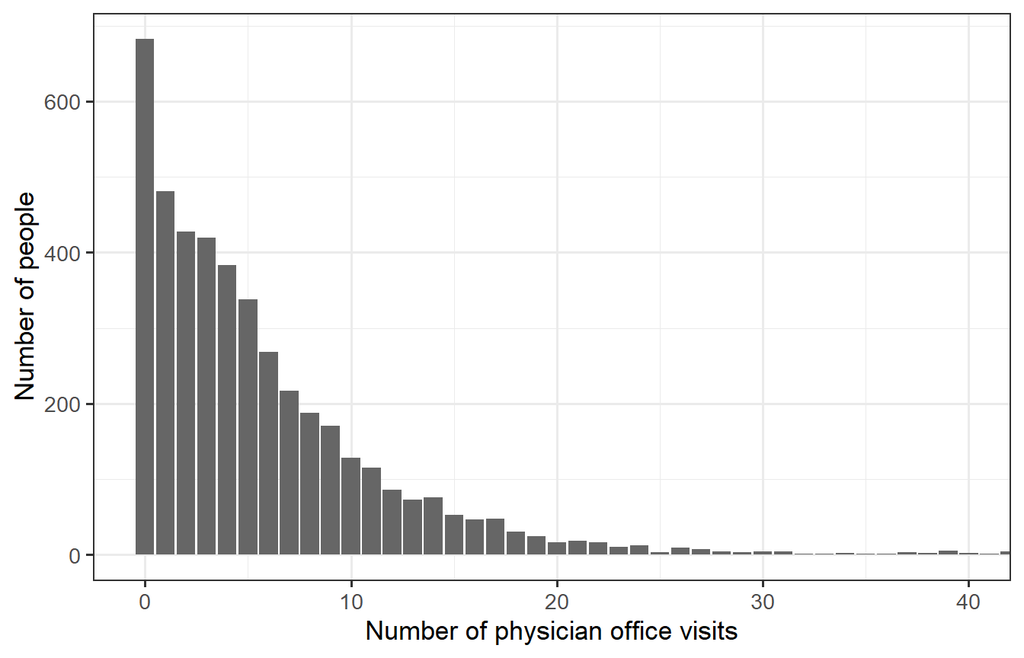

Figure 1: Distribution of the number of physician office visits (counts above 40 are not shown)

## Exploratory patterns

The outcome, `visits`, is a count: it takes only whole numbers and cannot be below zero. Across the 4,406 adults, the mean number of visits was 5.77 and the variance was 45.69, which is about 7.9 times the mean. A Poisson model assumes that the variance equals the mean, so this gap points to overdispersion. About 15.5% of people had no visits at all. The distribution has a long right tail, with a maximum of 89 visits, and 25 people (0.6%) had more than 40 visits. These unusually large counts are one reason to expect that a simple Poisson model may not fit well.

# 2. Specify competing count models

## Why not a linear model?

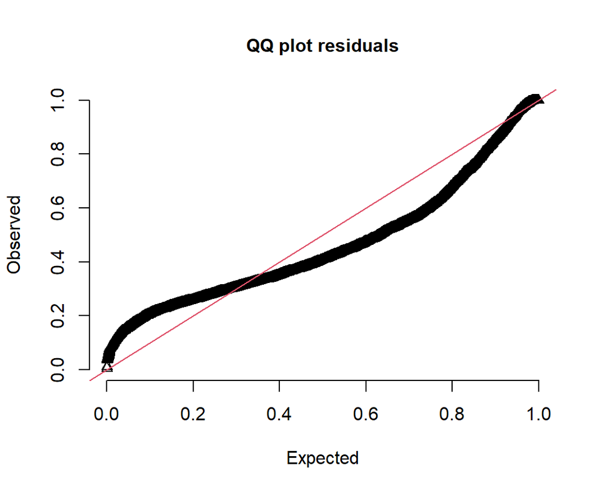

Figure 2: DHARMa QQ plot of simulated residuals for the Gaussian model

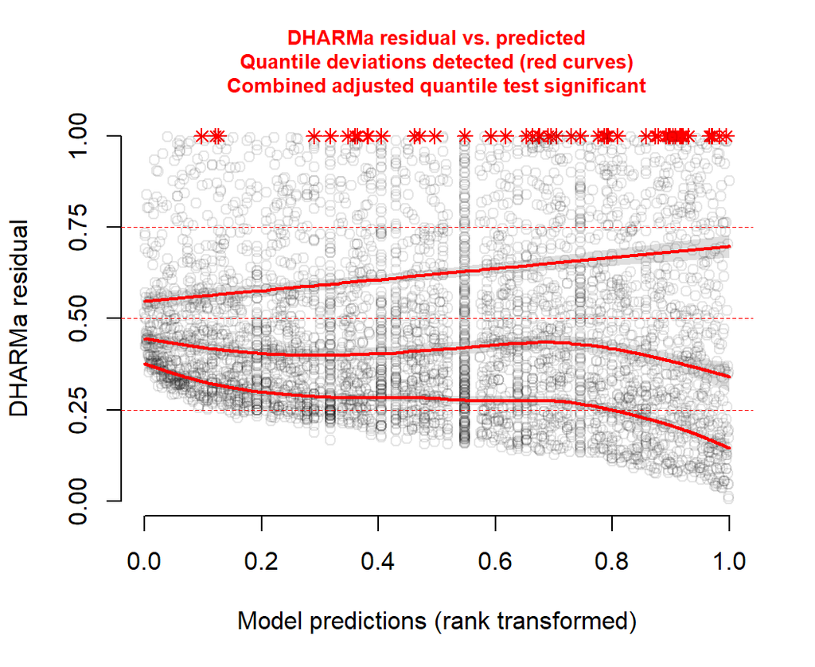

Figure 3: DHARMa residuals against model predictions for the Gaussian model

Table 2: DHARMa tests on the Gaussian model

| Test | Statistic | p |
| --- | --- | --- |
| Uniformity of residuals (KS) | 0.148 | < .001 |
| Dispersion | 1.001 | 0.960 |
| Outliers | 61.000 | < .001 |

A linear model is a poor choice for the number of physician visits. The DHARMa plots show that the simulated residuals from the Gaussian model do not behave as they should: the QQ plot departs from the diagonal,the formal tests in the table above flag deviations, and the residuals against the predicted values show structure instead of a flat, even spread. These departures appear because the model’s assumptions do not match the data. A Gaussian model treats the outcome as continuous, so it can predict a negative number of visits, which is impossible. It also assumes that the variance is the same at every level of the predictors, yet for counts the variance grows with the mean, so people who are expected to visit often are also the most variable. It treats each predictor as adding a fixed number of visits, whereas for counts it is more natural for a predictor to multiply the expected number of visits. Finally, it ignores that the outcome is made up of whole numbers, with a spike at zero and a long right tail.

## Three nested Poisson models

We will estimate three nested Poisson models with a log link:

| Model | Predictors | Purpose |
| --- | --- | --- |
| M0: Null | Intercept only | Baseline model |
| M1: Chronic | chronic | Evaluate the number of chronic conditions |
| M2: Full | chronic, health, gender, school, insurance | Additional contribution of the remaining predictors |

# 3. Compare the Poisson models

Table 3: Poisson model comparison and nested likelihood-ratio tests

| Model | AIC | BIC | logLik | deviance | Residual df | Nested df | Nested χ² | Nested p |
| --- | --- | --- | --- | --- | --- | --- | --- | --- |
| M0: Null | 39,720.34 | 39,726.73 | −19,859.17 | 39,718.34 | 4405 | — | — | — |
| M1: Chronic | 37,546.91 | 37,559.69 | −18,771.46 | 37,542.91 | 4404 | 1 | 2,175.43 | < .001 |
| M2: Full | 36,596.99 | 36,641.72 | −18,291.49 | 36,582.99 | 4399 | 5 | 959.92 | < .001 |

## Interpreting the comparison

Each likelihood-ratio test compares a model with the one before it. Adding the number of chronic conditions to the null model significantly improved fit (χ²(1) = 2175.4, p < .001), which tells us that chronic conditions are associated with the number of physician visits. Adding health, gender, education, and insurance to M1 also significantly improved fit (χ²(5) = 959.9, p < .001), so these predictors together explain additional variation beyond chronic conditions. I selected M2, the full Poisson model, because it had the lowest AIC (36,597.0) and BIC (36,641.7) and because both tests supported adding predictors. This selection is provisional: it assumes that a Poisson model is appropriate, which I check next.

# 4. Evaluate the Poisson model

## Simulated residuals

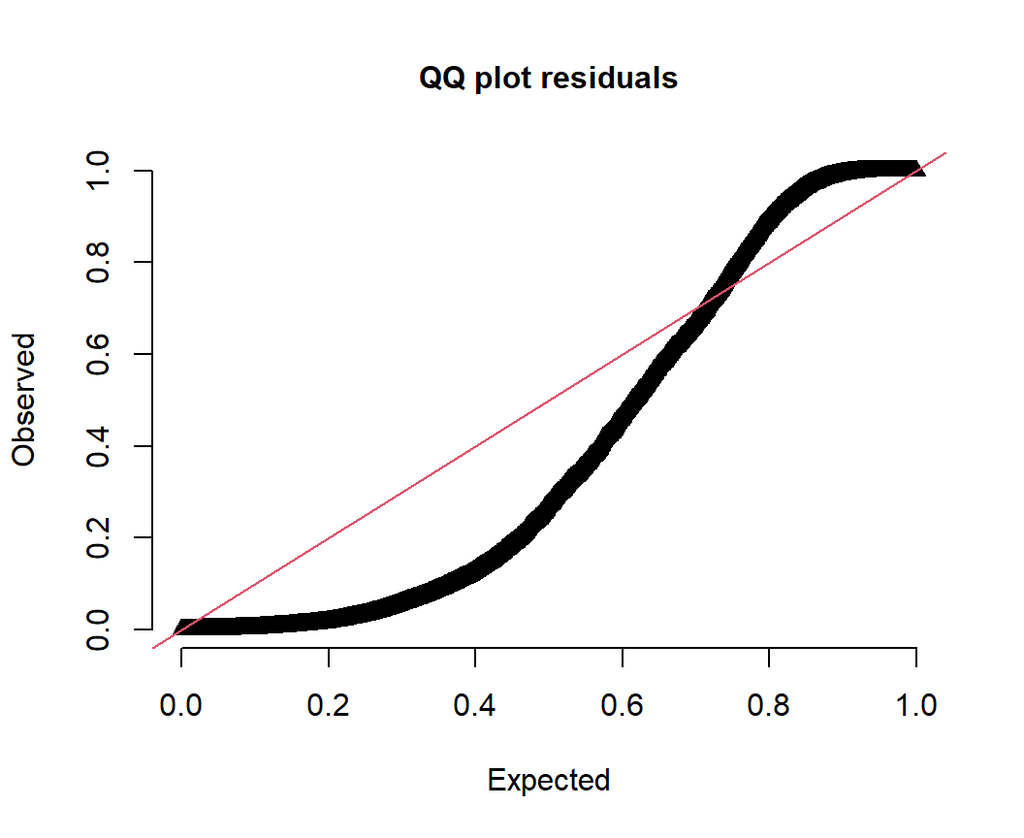

Figure 4: DHARMa QQ plot of simulated residuals for the full Poisson model

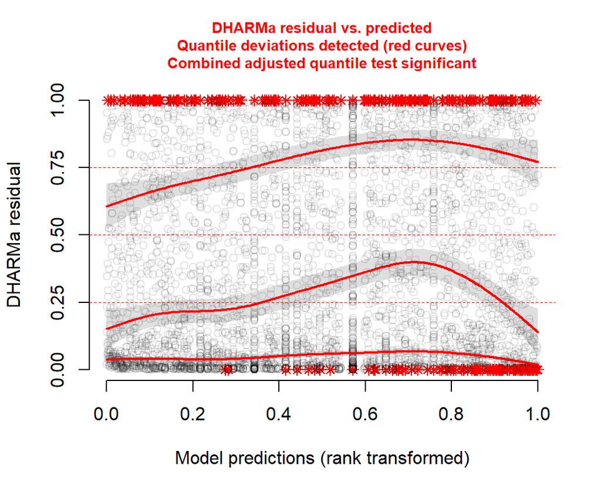

Figure 5: DHARMa residuals against model predictions for the full Poisson model

## Tests for overdispersion and excess zeros

Table 4: DHARMa tests on the full Poisson model

| Test | Statistic | p |
| --- | --- | --- |
| Dispersion ratio | 7.25 | < .001 |
| Observed / expected zeros | 15.03 | < .001 |

## Interpreting the Poisson diagnostics

The DHARMa diagnostic plots suggest that the Poisson model does not fit the data well. The simulated residuals deviate from the diagonal in the Q-Q plot, and the residuals plotted against predicted values show a pattern rather than an even spread. The dispersion ratio was 7.25 (*p* < .001), indicating substantial overdispersion relative to what the Poisson model expects. In addition, the observed number of zeros was 15.03 times the number expected by the model (*p* < .001).

Overdispersion is a concern because the Poisson model assumes that the variance equals the mean. When the observed variability is greater than expected, the model underestimates the uncertainty in its estimates, which produces standard errors that are too small, confidence intervals that are too narrow, and potentially misleading *p*-values. Consequently, predictors may appear more statistically significant than the data support.

However, a significant zero-inflation test does not necessarily mean that a zero-inflated model is needed. Overdispersion can also produce more zeros than a Poisson model predicts, so the apparent excess of zeros may be explained by the greater variability in the data. It is therefore more appropriate to first address overdispersion with a negative binomial (NB2) model, which allows the variance to exceed the mean. The diagnostic tests can then be repeated to determine whether excess zeros remain after accounting for overdispersion.

# 5. Fit and evaluate a negative binomial model

## Estimate the NB2 model

## Compare the Poisson and the NB2

Table 5: Likelihood-ratio test comparing the Poisson and negative binomial models

| Model | AIC | BIC | logLik | χ² | df | p |
| --- | --- | --- | --- | --- | --- | --- |
| Poisson (M2) | 36,596.99 | 36,641.72 | −18,291.49 | — | — | — |
| Negative binomial (NB2) | 24,469.91 | 24,521.03 | −12,226.95 | 12,129.08 | 1 | < .001 |

The negative binomial model fit significantly better than the Poisson model, χ²(1) = 12,129.1, p < .001. The test has 1 degree of freedom because the NB2 differs from the Poisson by exactly one parameter: the dispersion parameter, which lets the variance exceed the mean. The Poisson is the special case in which that extra variance is zero.

The comparison changes how the Poisson results should be read. Allowing for overdispersion made the standard errors about 2.5 times larger on average than under the Poisson model, which means the Poisson model was overstating how precisely the associations were estimated. None of the predictors changed from significant to non-significant, so the conclusions about the direction of the associations were stable, even though the uncertainty was larger. In other words, the conclusions I would have drawn from the Poisson model were too confident, even where they were not wrong.

## Re-check the NB2 with DHARMa

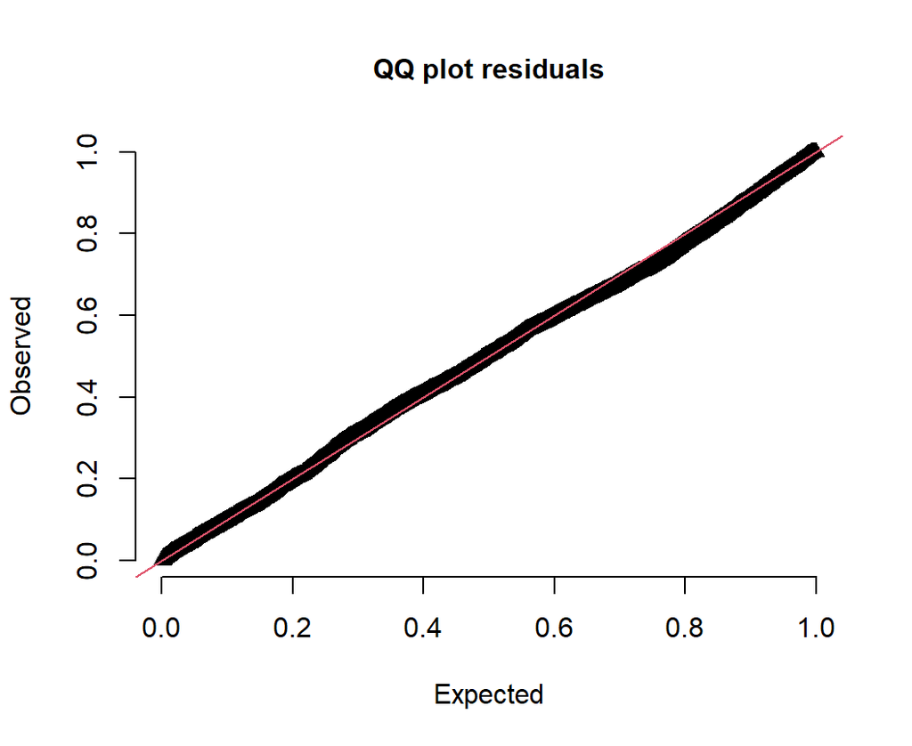

Figure 6: DHARMa QQ plot of simulated residuals for the negative binomial model

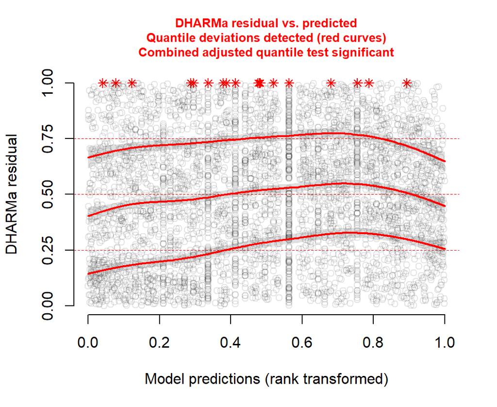

Figure 7: DHARMa residuals against model predictions for the negative binomial model

Table 6: DHARMa tests on the negative binomial model

| Test | Statistic | p |
| --- | --- | --- |
| Dispersion ratio | 1.04 | 0.428 |
| Observed / expected zeros | 1.10 | 0.008 |

The negative binomial model resolved the overdispersion. The dispersion ratio fell from 7.25 under the Poisson model to 1.04 (p = .428), which is close to 1 and not significant. The residual plots also improved: the QQ plot now follows the diagonal closely, although the plot of residuals against predictions still shows some mild curvature in the quantile lines. One problem remains. The ratio of observed to expected zeros fell from 15.03 to 1.10, but it is still significantly different from 1 (p = .008), which means that the NB2 still produces somewhat fewer zeros than were observed. The excess is small, about 10% more zeros than expected, but because the test is significant I examine in the next section whether the zeros need their own model.

## Visualize predicted counts

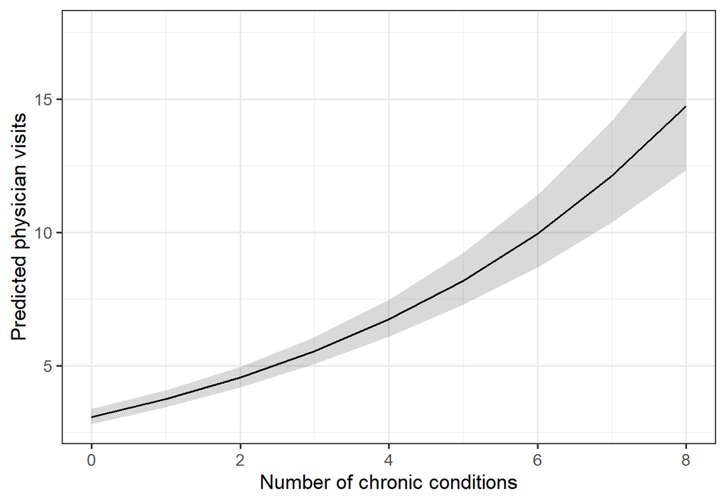

Figure 8: Predicted number of physician visits by number of chronic conditions (negative binomial model)

The line curves upward even though the model is linear in its predictors. This is the effect of the log link: each additional chronic condition adds a constant amount on the log scale, which multiplies the expected number of visits by a constant factor. The same one-condition increase therefore adds more visits when the expected count is already high than when it is low.

# 6. Decide whether the zeros need their own model

The negative binomial model still predicts slightly fewer zeros than observed, so I fit two models that give the zeros their own process, using the same five predictors in both the count part and the zero part.

- **Zero-inflated negative binomial (ZINB):** the zero part models the probability of a structural zero, and some zeros also come from the count part.
- **Hurdle negative binomial:** the zero part models zero versus non-zero, so all zeros come from that part, and a truncated NB2 handles the positive counts.

Table 7: Comparison of the negative binomial, zero-inflated negative binomial, and hurdle models

| Model | df | logLik | AIC | BIC |
| --- | --- | --- | --- | --- |
| NB2 | 8 | −12,226.95 | 24,469.91 | 24,521.03 |
| ZINB | 15 | −12,155.39 | 24,340.77 | 24,436.63 |
| Hurdle NB | 15 | −12,150.20 | 24,330.41 | 24,426.27 |

The ZINB fit significantly better than the NB2, χ²(7) = 143.1, p < .001.

Table 8: DHARMa tests on the zero-inflated and hurdle models

| Model | Dispersion ratio | p | Observed / expected zeros | p |
| --- | --- | --- | --- | --- |
| ZINB | 1.19 | 0.008 | 0.96 | 0.172 |
| Hurdle NB | 1.15 | 0.004 | 1.00 | 1.000 |

## Re-check the chosen model

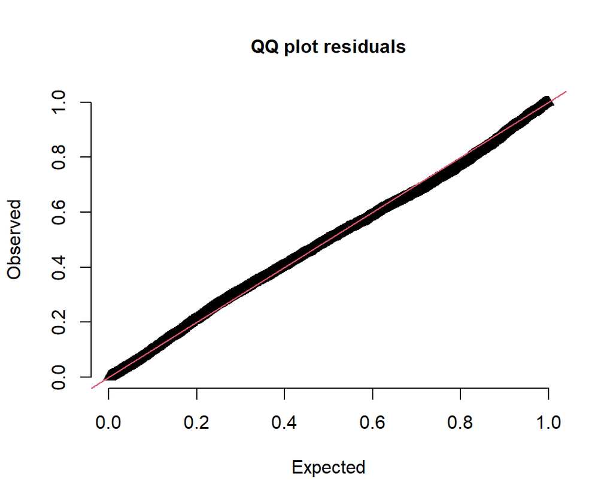

Figure 9: DHARMa QQ plot of simulated residuals for the hurdle negative binomial model

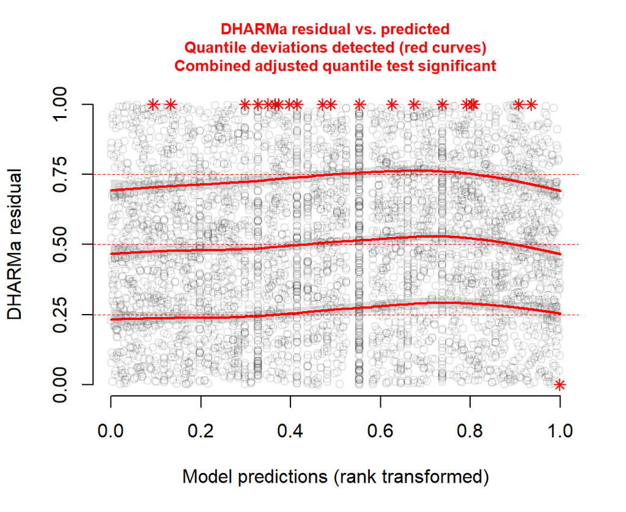

Figure 10: DHARMa residuals against model predictions for the hurdle negative binomial model

## Justifying the choice

I selected the hurdle negative binomial model to carry forward. The DHARMa zero-inflation test showed that the NB2 still produced fewer zeros than observed (observed/expected = 1.10, *p* = .008), so the zeros needed to be modelled separately. The ZINB fit significantly better than the NB2 (χ²(7) = 143.1, p < .001). AIC and BIC agreed that the hurdle model was best of the three: its AIC was 24,330.4 compared with 24,340.8 for the ZINB and 24,469.9 for the NB2, and its BIC was 24,426.3 compared with 24,436.6 and 24,521.0. The hurdle model reproduced the observed zeros (observed/expected = 1.00, *p* > .999), and the ZINB did so as well (0.96, p = .172), so the choice between them rests on AIC and BIC. The hurdle model also has a natural interpretation for physician visits: one part asks whether a person had any visit at all, and the other asks how many visits they made among those who did. One caution is that the dispersion tests were slightly significant for both zero models (hurdle ratio = 1.15, p = .004), although the ratios are close to 1 and a test on 4,406 observations can flag small departures. I treat this as a minor limitation and not as a reason to prefer the NB2, which cannot reproduce the zeros.

# 7. Test and probe an interaction

**Question:** Does the association between the number of chronic conditions and physician visits differ between people with and without private insurance?

## Prediction

I predicted that the association between the number of chronic conditions and physician visits would be stronger for people with private insurance than for people without it. Private insurance lowers the cost of seeing a doctor, so insured people with more chronic conditions should find it easier to make additional visits for their health needs, whereas people without private insurance may limit their visits even when they have many conditions. I therefore expected a steeper positive slope of chronic conditions for the insured group.

## Fit the interaction model

The interaction is added to the count part of the hurdle model, so it concerns the number of visits among people who made at least one visit. The zero part keeps all five predictors as additive controls.

## Test whether the interaction is needed

A likelihood-ratio test comparing the additive hurdle model with the interaction model gave χ²(1) = 0.34, p = .559. The interaction did not significantly improve model fit.

This omnibus test only tells us whether the slope of chronic conditions differs by insurance status. It does not tell us how large the slope is in each group, whether each slope is different from zero, or at what numbers of chronic conditions the groups differ. Probing the interaction answers those questions.

## Plot predicted counts

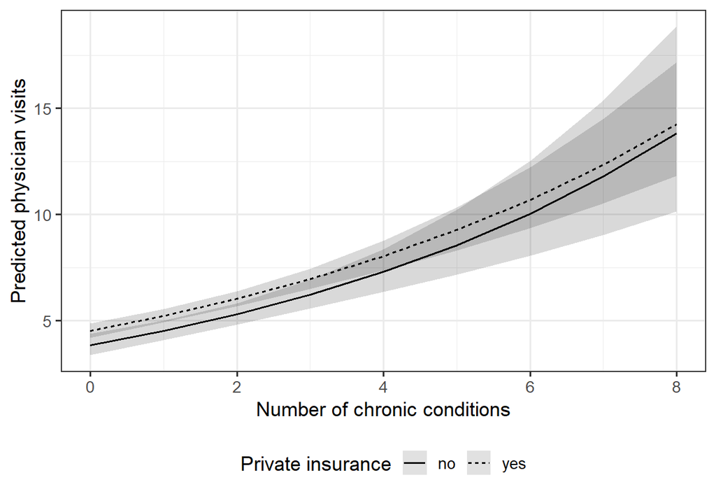

Figure 11: Predicted physician visits by number of chronic conditions and private insurance status (hurdle negative binomial, count part)

## Probe the interaction with emmeans

### Simple slopes

Table 9: Simple slopes of chronic conditions within each insurance group (log scale)

| Private insurance | Slope (b) | SE | 95% CI Lower | 95% CI Upper | p |  |
| --- | --- | --- | --- | --- | --- | --- |
| no | 0.160 | 0.025 | 0.111 | 0.208 |  | < .001 |
| yes | 0.143 | 0.014 | 0.115 | 0.172 | < .001 |  |

Comparing the two slopes with `pairs()` gave a difference of 0.016 (SE = 0.028, p = .560). This reproduces the interaction coefficient from the model (-0.016, SE = 0.028, p = .560) with the sign flipped, because `pairs()` computes the slope for people without insurance minus the slope for people with insurance, whereas the coefficient is the extra slope for people with insurance. The two tests answer the same question when the moderator has only two levels, because the difference between the two slopes is exactly the interaction coefficient. The small difference between the p-value here and the likelihood-ratio p-value above arises because `pairs()` uses a Wald z-test and the omnibus test is a likelihood-ratio test.

### Simple effects

Table 10: Predicted physician visits (emmeans) by insurance status and number of chronic conditions

| Private insurance | Chronic conditions | Predicted visits | SE |
| --- | --- | --- | --- |
| no | 0.19 | 4.04 | 0.25 |
| yes | 0.19 | 4.73 | 0.17 |
| no | 1.54 | 5.01 | 0.23 |
| yes | 1.54 | 5.74 | 0.17 |
| no | 2.89 | 6.21 | 0.31 |
| yes | 2.89 | 6.96 | 0.23 |

The predicted counts from `emmeans` can differ slightly from the plot above. The plot holds the other predictors at their reference levels or means (average health, male, and mean education), whereas `emmeans` averages across the levels of health and gender. Both are valid, but they describe slightly different baselines. The contrasts between the insurance groups are the same either way, because no interaction involves health, gender, or education, so their effects cancel out of the comparison on the log scale.

## Simple effects table

Table 11: Simple effects of private insurance at low, average, and high numbers of chronic conditions

| Chronic conditions | Contrast | Log contrast | SE | z | p |
| --- | --- | --- | --- | --- | --- |
| -1 SD | no - yes | −0.158 | 0.065 | −2.450 | 0.014 |
| Mean | no - yes | −0.136 | 0.045 | −3.055 | 0.002 |
| +1 SD | no - yes | −0.114 | 0.052 | −2.199 | 0.028 |

Contrasts are no insurance minus insurance. Tests are computed on the log scale.

## Interpreting the interaction

There is little evidence that the association between the number of chronic conditions and physician visits differs by private insurance. The likelihood-ratio test was not significant (χ²(1) = 0.34, p = .559), and the simple slopes were very similar: each additional chronic condition was associated with an increase of .16 in the log expected count for people without private insurance and .14 for people with it, and both slopes were significantly different from zero. The difference between the slopes was small (.016, p = .560), and it was in the opposite direction from my prediction, because the slope was slightly smaller, not larger, for insured people. The probing of the simple effects adds a separate piece of information. People without private insurance were expected to make fewer visits than people with it at low, average, and high numbers of chronic conditions (log contrasts of -.16, -.14, and -.11, all p < .05), so insurance was associated with more visits at every level. That is a difference in level, however, and not a difference in slope, so it does not contradict the non-significant interaction. I am fairly confident that the interaction is small or absent: the omnibus test and the slope comparison agree, and the 95% confidence interval for the difference in slopes, [-.07, .04], is narrow enough to rule out a large difference, although it cannot rule out a small one.

# 8. Coefficients of the selected model

Table 12: Coefficients from the hurdle negative binomial model (log scale)

| Predictor | b | SE | 95% CI Lower | 95% CI Upper | p |  |
| --- | --- | --- | --- | --- | --- | --- |
| Count part (log expected visits among people with at least one visit) |  |  |  |  |  |  |
| Intercept | 1.520 | 0.073 | 1.377 | 1.664 |  | < .001 |
| Chronic conditions (per condition) | 0.148 | 0.013 | 0.123 | 0.172 | < .001 |  |
| Health: poor (vs. average) | −0.383 | 0.049 | −0.478 | −0.287 | < .001 |  |
| Health: excellent (vs. average) | −0.751 | 0.081 | −0.910 | −0.592 | < .001 |  |
| Gender: female (vs. male) | 0.056 | 0.033 | −0.008 | 0.121 | 0.088 |  |
| Education (per year) | 0.021 | 0.005 | 0.012 | 0.030 | < .001 |  |
| Private insurance: yes (vs. no) | 0.130 | 0.044 | 0.045 | 0.216 | 0.003 |  |
| Zero part (log-odds of having zero visits) |  |  |  |  |  |  |
| Intercept | 0.277 | 0.199 | −0.113 | 0.667 | 0.164 |  |
| Chronic conditions (per condition) | −0.558 | 0.045 | −0.647 | −0.470 | < .001 |  |
| Health: poor (vs. average) | 0.050 | 0.160 | −0.263 | 0.363 | 0.754 |  |
| Health: excellent (vs. average) | 0.359 | 0.208 | −0.049 | 0.767 | 0.085 |  |
| Gender: female (vs. male) | −0.401 | 0.087 | −0.573 | −0.230 | < .001 |  |
| Education (per year) | −0.058 | 0.012 | −0.082 | −0.035 | < .001 |  |
| Private insurance: yes (vs. no) | −0.747 | 0.101 | −0.944 | −0.550 | < .001 |  |

# 9. Results

The outcome, the number of physician office visits, was overdispersed (*M* = 5.77, *s*² = 45.69), and 15.5% of people had no visits. DHARMa residual checks on the full Poisson model showed significant overdispersion (dispersion ratio = 7.25, *p* < .001) and excess zeros (observed/expected = 15.03, *p* < .001). A negative binomial model fit significantly better, χ²(1) = 12,129.1, *p* < .001, and removed the overdispersion (ratio = 1.04, *p* = .428), but it still underpredicted the zeros (observed/expected = 1.10, *p* = .008), so a separate model for the zeros was needed. A hurdle negative binomial model had the lowest AIC and BIC of the models considered and reproduced the observed zeros (observed/expected = 1.00, *p* > .999), so it was selected as the final model.

Coefficients are on the log scale. Holding the other predictors constant, the count part of the hurdle model, which describes the number of visits among people who made at least one visit, showed that each additional chronic condition was associated with more visits (*b* = .15, 95% CI [.12, .17], *p* < .001). Compared with people in average health, both people in poor health (*b* = -.38, 95% CI [-.48, -.29], *p* < .001) and people in excellent health (*b* = -.75, 95% CI [-.91, -.59], *p* < .001) had fewer expected visits. More years of education (*b* = .021, 95% CI [.012, .030], *p* < .001) and having private insurance (*b* = .13, 95% CI [.05, .22], *p* = .003) were associated with more visits, whereas gender was not significantly associated with the number of visits (female vs. male: *b* = .06, 95% CI [-.01, .12], *p* = .088). The zero part of the model describes the log-odds of having no visits at all. Holding the other predictors constant, people with more chronic conditions (*b* = -.56, 95% CI [-.65, -.47], *p* < .001), women (*b* = -.40, 95% CI [-.57, -.23], *p* < .001), people with more education (*b* = -.058, 95% CI [-.082, -.035], *p* < .001), and people with private insurance (*b* = -.75, 95% CI [-.94, -.55], *p* < .001) were less likely to have no visits. Neither poor health (*b* = .05, 95% CI [-.26, .36], *p* = .754) nor excellent health (*b* = .36, 95% CI [-.05, .77], *p* = .085) was significantly associated with the odds of having no visits.

Adding a chronic conditions × private insurance interaction to the count part did not significantly improve model fit, χ²(1) = 0.34, *p* = .559. Simple slopes showed that chronic conditions were significantly associated with more visits both for people without private insurance (*b* = .16, 95% CI [.11, .21], *p* < .001) and for people with it (*b* = .14, 95% CI [.12, .17], *p* < .001). Simple effects showed that people without private insurance were expected to make fewer visits than people with it at −1 *SD* of chronic conditions (log contrast = -.16, *p* = .014), at the mean (log contrast = -.14, *p* = .002), and at +1 *SD* (log contrast = -.11, *p* = .028). Overall, the slope of chronic conditions did not differ by insurance status, but private insurance was associated with more visits at every level of chronic conditions.

# 10. Discussion and limitations

Among these older adults, the number of chronic conditions was the most consistent predictor of physician visits. It was associated with both parts of the hurdle model. Each additional chronic condition was associated with approximately 16% more expected visits among individuals who visited a physician at least once, as well as lower odds of having no visits (OR = .57). Adding chronic conditions to the null model also produced a much larger improvement in model fit (χ² = 2,175) than adding the four remaining predictors together (χ² = 960). This suggests that chronic conditions made an important contribution to explaining physician visits, although these improvements should be interpreted in the context of the order in which predictors were added. Private insurance, education, and gender were also associated with whether individuals visited a physician. Those with private insurance, higher education levels, and women had lower odds of having no visits. In addition, individuals with private insurance or higher education had more visits among those who sought care. The relationship between self-perceived health and physician visits was less straightforward. Although individuals reporting poor health had more visits than those reporting average health in the raw data, both poor and excellent health were associated with fewer visits than average health after accounting for chronic conditions in the count model. This may reflect the overlap between self-perceived health and chronic conditions, which were more common among individuals reporting poor health. Finally, the relationship between chronic conditions and physician visits was similar regardless of insurance status, although insured individuals had more visits across all levels of chronic conditions.

Several limitations should be considered when interpreting these findings. First, the data are observational and come from a single survey of adults aged 66 and older conducted between 1987 and 1988. Therefore, the results describe associations rather than causal relationships and may not generalize to other populations or reflect current healthcare patterns. Second, both physician visits and self-perceived health were self-reported, which may introduce reporting inaccuracies. The model also did not account for other potentially important factors, such as income, additional types of insurance, or hospital stays, which could influence the observed relationships. Another limitation concerns model fit. Although the hurdle model was selected based on AIC, BIC, and the DHARMa diagnostics, a small amount of overdispersion remained (dispersion ratio = 1.15, *p* = .004). This suggests that some variability was not fully accounted for and could affect the reliability of the standard errors. Also, the ZINB model performed similarly but handles zeros differently, meaning that interpretations of the zero-generating process depend partly on the model selected. Finally, the interaction analysis only examined whether insurance modified the relationship between chronic conditions and the number of visits among individuals who visited a physician. Therefore, it cannot determine whether insurance also influences the relationship between chronic conditions and the likelihood of having any physician visits.